# Ćwiczenia 2

### Katarzyna Foryszewska

```python
import numpy as np
import matplotlib.pyplot as plt
```

```python
#Klasa dedykowana regresji liniowej 2 zmiennych

class LinearModel2v:
    def __init__(self, eta = 0.001, diff = 0.001, w1 = 1, w2 = 1, w0 = 1, maxiter = 10000):
        self.eta = eta
        self.diff = diff
        self.w1 = w1
        self.w2 = w2
        self.w0 = w0
        self.maxiter = maxiter

    def loss_function(self, X, t):
        N = len(X)
        C = 0
        for i in range(N):
            C += (X[i][0]*self.w1+X[i][1]*self.w2+self.w0-t[i])**2
        return C/(2*N)

    def update_weights(self, X, t):
        N = len(X)
        dC1 = 0
        dC2 = 0
        dC0 = 0
        for i in range(N):
            y_pred = X[i][0]*self.w1+X[i][1]*self.w2+self.w0
            dC1 += 2*X[i][0]*(y_pred-t[i])
            dC2 += 2*X[i][1]*(y_pred-t[i])
            dC0 += 2*(y_pred-t[i])

        self.w1 = self.w1 - self.eta*dC1/(2*N)
        self.w2 = self.w2 - self.eta*dC2/(2*N)
        self.w0 = self.w0 - self.eta*dC0/(2*N)

    def train(self, X, t):
        l = []
        ile = 0
        while True:
            l.append(self.loss_function(X, t))
            self.update_weights(X, t)
            ile += 1
            if len(l)>2:
                if abs(l[-1]-l[-2])/l[-1] <  self.diff or ile > self.maxiter:
                    break
```

```python
X = np.array([[1,4],[5,6],[2,2],[6,7],[9,-4],[-2,-3],[-5,1]])
y = np.dot(X, [3, -4])+5  #y=3x1-4x2+5
```

```python
model = LinearModel2v()
model.train(X, y)
```

```python
model.w1, model.w2, model.w0, model.loss_function(X, y)
```

```
(3.000309260729557,
 -3.999675320045806,
 4.99577829150021,
 6.215829033587025e-06)
```

## Regresja wielomianowa

```python
from sklearn.preprocessing import PolynomialFeatures
from sklearn.linear_model import LinearRegression
from sklearn.pipeline import make_pipeline

def PolynomialRegression(degree=2, **kwargs):
    return make_pipeline(PolynomialFeatures(degree), LinearRegression(**kwargs))
```

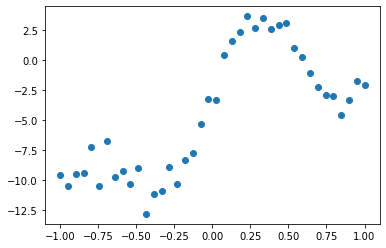

```python
rng = np.random.RandomState(1)
x = np.linspace(-1, 1, 40)
y = 3*x**3 - 4*x**2 + 6*x - 3 + 5*np.sin(5*x) + rng.randn(40)

plt.scatter(x,y)
plt.show()
```

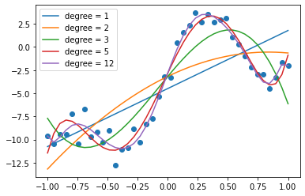

```python
plt.scatter(x,y)

for d in [1, 2, 3, 5, 12]:
    y_pred = PolynomialRegression(d).fit(x[:, np.newaxis], y).predict(x[:, np.newaxis])
    plt.plot(x, y_pred, label = f"degree = {d}")

plt.legend(loc = "best")
plt.show()
```

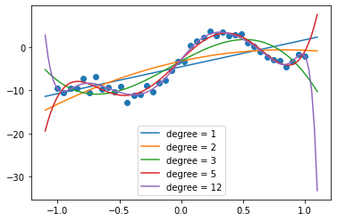

```python
#a jak to jest na większym przedziale?
plt.scatter(x,y)

for d in [1, 2, 3, 5, 12]:
    y_pred = PolynomialRegression(d).fit(x[:, np.newaxis], y).predict(np.linspace(-1.1,1.1,100)[:, np.newaxis])
    plt.plot(np.linspace(-1.1,1.1,100), y_pred, label = f"degree = {d}")

plt.legend(loc = "best")
plt.show()
```

### Regularyzacja

Wprowadzenie szerszej klasy funkcji bazowych jak i ilości parametrów może bardzo szybko prowadzić do zjawiska overfittingu (przetrenowania). Jak sobie z tym poradzić? Na przykład, wprowadzając pewne dodatkowe obciążenie do funkcji kosztu zależne od współczynników:

Regularyzacja L2 (Ridge Regression): $LF^+ = \alpha \sum_{i} w_{i}^2$

Regularyzacja L1 (Lasso Regression): $LF^+ = \alpha \sum_{i} |w_{i}|^2$

tzn. $LF_{new} = LF + LF^+$

## Zadanie 1:

Zdefiniuj klasę implementującą regresję liniową z regularyzacją L1/L2 dla dowolnej liczby zmiennych.

```python
class ModelRidge:
    def __init__(self, eta = 0.001, diff = 0.001, w1 = 1, w2 = 1, w0 = 1, maxiter = 10000):
        self.eta = eta
        self.diff = diff
        self.w1 = w1
        self.w2 = w2
        self.w0 = w0
        self.maxiter = maxiter

    def loss_function(self, X, t):
        N = len(X)
        C = 0
        alpha = 0.5
        for i in range(N):
            lr = (X[i][0]*self.w1+X[i][1]*self.w2+self.w0-t[i])**2
            rr = alpha*(self.w1**2+self.w2**2+self.w0**2)
            C += lr
            LR = lr/(2*N)
            total = LR + rr

        return total #chodzi o zastosowanie LF_new = LF + LF+, prawda?

    def update_weights(self, X, t):
        N = len(X)
        dC1 = 0
        dC2 = 0
        dC0 = 0
        for i in range(N):
            y_pred = X[i][0]*self.w1+X[i][1]*self.w2+self.w0
            dC1 += 2*X[i][0]*(y_pred-t[i])
            dC2 += 2*X[i][1]*(y_pred-t[i])
            dC0 += 2*(y_pred-t[i])

        self.w1 = self.w1 - self.eta*dC1/(2*N)
        self.w2 = self.w2 - self.eta*dC2/(2*N)
        self.w0 = self.w0 - self.eta*dC0/(2*N)

    def train(self, X, t):
        l = []
        ile = 0
        while True:
            l.append(self.loss_function(X, t))
            self.update_weights(X, t)
            ile += 1
            if len(l)>2:
                if abs(l[-1]-l[-2])/l[-1] <  self.diff or ile > self.maxiter:
                    break
```

```python
X = np.array([[1,4],[5,6],[2,2],[6,7],[9,-4],[-2,-3],[-5,1]])
y = np.dot(X, [3, -4])+5  #y=3x1-4x2+5
```

```python
model = ModelRidge()
model.train(X, y)
```

```python
model.w1, model.w2, model.w0, model.loss_function(X, y)
```

```
(1.914563765999958, -1.1739441182458017, 1.0151694485769136, 4.338512254660383)
```

```python
from sklearn.linear_model import RidgeClassifier #albo tak?
```

## Zadanie 2:

Wybierz dowolny zbiór danych lub wygeneruj syntetyczne dane. Zastosuj model regresji liniowej z regularyzacją L1. Na podstawie zbioru walidacyjnego wybierz optymalne parametry $\eta$ oraz $\alpha$ (rozważ chociaż 15-20 różnych kombinacji).

```python
class ModelRidge:
    def __init__(self, eta, diff, w1, w2, w0, alpha, maxiter):
        self.eta = eta
        self.diff = diff
        self.w1 = w1
        self.w2 = w2
        self.w0 = w0
        self.alpha = alpha
        self.maxiter = maxiter

    def loss_function(self, A, t):
        N = len(X)
        suma = 0
        for i in range(N):
            lr = (A[i][0]*self.w1+A[i][1]*self.w2+self.w0-t[i])**2
            rr = self.alpha*(self.w1**2+self.w2**2+self.w0**2)
            suma += lr
            LR = lr/(2*N)
            total = LR + rr

        return total #chodzi o zastosowanie LF_new = LF + LF+, prawda?

    def update_weights(self, A, t):
        N = len(A)
        dC1 = 0
        dC2 = 0
        dC0 = 0
        for i in range(N):
            b_pred = A[i][0]*self.w1+X[i][1]*self.w2+self.w0
            dC1 += 2*A[i][0]*(b_pred-t[i])
            dC2 += 2*A[i][1]*(b_pred-t[i])
            dC0 += 2*(b_pred-t[i])

        self.w1 = self.w1 - self.eta*dC1/(2*N)
        self.w2 = self.w2 - self.eta*dC2/(2*N)
        self.w0 = self.w0 - self.eta*dC0/(2*N)

    def train(self, A, t):
        l = []
        ile = 0
        while True:
            l.append(self.loss_function(A, t))
            self.update_weights(A, t)
            ile += 1
            if len(l)>2:
                if abs(l[-1]-l[-2])/l[-1] <  self.diff or ile > self.maxiter:
                    break
```

```python
A = np.array([[15,-30],[12,16],[26,-20],[10,7],[19,-4], [6,1], [-1, -1]])
b = np.dot(X, [15, -8])+6
```

```python
model = ModelRidge(0.01, 0.001, 1, 1, 1, 0.5, 1000) #zmieniam etę przy stałej alphie
model.train(A, b)

model.w1, model.w2, model.w0, model.loss_function(A, b)
```

```
(9.40111083159718e+37,
 -4.99246601028663e+37,
 5.170431090622984e+36,
 1.1465468987181091e+76)
```

```python
model = ModelRidge(0.001, 0.001, 1, 1, 1, 0.5, 1000) #zmieniam etę przy stałej alphie
model.train(A, b)

model.w1, model.w2, model.w0, model.loss_function(A, b)
```

```
(2.1248902735202617, 8.58309645355421, 0.6768206129365169, 359.66601706181893)
```

```python
model = ModelRidge(0.0001, 0.001, 1, 1, 1, 0.5, 1000) #zmieniam etę przy stałej alphie
model.train(A, b)

model.w1, model.w2, model.w0, model.loss_function(A, b)
```

```
(1.7230078101511506, 1.4218456799938834, 1.0121480595476733, 403.3725506688388)
```

```python
model = ModelRidge(0.00001, 0.001, 1, 1, 1, 0.5, 1000) #zmieniam etę przy stałej alphie
model.train(A, b)

model.w1, model.w2, model.w0, model.loss_function(A, b)
```

```
(1.0116561764458578, 1.004015845862115, 1.0003027573511563, 413.9206299608573)
```

```python
model = ModelRidge(0.01, 0.001, 1, 1, 1, 0.1, 1000) #zmieniam alphę przy wybranej ecie
model.train(A, b)

model.w1, model.w2, model.w0, model.loss_function(A, b)
```

```
(9.40111083159718e+37,
 -4.99246601028663e+37,
 5.170431090622984e+36,
 1.2439048094187961e+75)
```

```python
model = ModelRidge(0.01, 0.001, 1, 1, 1, 0.01, 1000) #zmieniam alphę przy wybranej ecie
model.train(A, b)

model.w1, model.w2, model.w0, model.loss_function(A, b)
```

```
(4.691919669404251,
 12.552941555044196,
 0.45918627152344316,
 260.78122310149047)
```

```python
model = ModelRidge(0.01, 0.001, 1, 1, 1, 1, 1000) #zmieniam alphę przy wybranej ecie
model.train(A, b)

model.w1, model.w2, model.w0, model.loss_function(A, b)
```

```
(9.40111083159718e+37,
 -4.99246601028663e+37,
 5.170431090622984e+36,
 1.1465468987181091e+76)
```

```python
model = ModelRidge(0.01, 0.001, 1, 1, 1, 2, 1000) #zmieniam alphę przy wybranej ecie
model.train(A, b)

model.w1, model.w2, model.w0, model.loss_function(A, b)
```

```
(9.40111083159718e+37,
 -4.99246601028663e+37,
 5.170431090622984e+36,
 2.2822762518028086e+76)
```

## Zadanie dodatkowe

```python
class ModelRidge:
    def __init__(self, eta = 0.001, diff = 0.001, w1 = 1, w2 = 1, w0 = 1, maxiter = 10000):
        self.eta = eta
        self.diff = diff
        self.w1 = w1
        self.w2 = w2
        self.w0 = w0
        self.maxiter = maxiter

    def loss_function(self, X, t):
        N = len(X)
        C = 0
        alpha = 0.5
        for i in range(N):
            lr = (X[i][0]*self.w1+X[i][1]*self.w2+self.w0-t[i])**2
            ridge = alpha*(self.w1**2+self.w2**2+self.w0**2)
            lasso = alpha*(abs(self.w1)+abs(self.w2)+abs(self.w0))
            C += lr
            LR = lr/(2*N)
            total = LR + ridge + lasso

        return total #tak???

    def update_weights(self, X, t):
        N = len(X)
        dC1 = 0
        dC2 = 0
        dC0 = 0
        for i in range(N):
            y_pred = X[i][0]*self.w1+X[i][1]*self.w2+self.w0
            dC1 += 2*X[i][0]*(y_pred-t[i])
            dC2 += 2*X[i][1]*(y_pred-t[i])
            dC0 += 2*(y_pred-t[i])

        self.w1 = self.w1 - self.eta*dC1/(2*N)
        self.w2 = self.w2 - self.eta*dC2/(2*N)
        self.w0 = self.w0 - self.eta*dC0/(2*N)

    def train(self, X, t):
        l = []
        ile = 0
        while True:
            l.append(self.loss_function(X, t))
            self.update_weights(X, t)
            ile += 1
            if len(l)>2:
                if abs(l[-1]-l[-2])/l[-1] <  self.diff or ile > self.maxiter:
                    break
```

```python
model.w1, model.w2, model.w0, model.loss_function(X, y)
```

[output not shown]

```python
model = ModelRidge()
model.train(X, y)
```